[figure not shown]

AC(diag)-6

Auto A/C Control Module I/O Signal

HVAC SYSTEM (AUTO A/C) (DIAGNOSTICS)

4. Auto A/C Control Module I/O Signal

A: ELECTRICAL SPECIFICATION

Terminal No. Contents Measuring condition Standard

1 Mode door actuator #4 Digital signal; can not be measured —

2 Mode door actuator #3 Digital signal; can not be measured —

3 Mode door actuator #2 Digital signal; can not be measured —

4 Mode door actuator #1 Digital signal; can not be measured —

6 Intake door actuator (FRESH) FRESH mode 8 V or more

8 Intake door actuator (RECIRC) RECIRC mode 8 V or more

9 Blower fan ON signal Blower fan is ON 1 V or less

10

Intake door potentiometer power

supply

Ignition switch ON 5 V

11 A/C cut-off signal A/C is cut off 1 V or less

12 Intake door potentiometer signal Ignition switch ON 0 — 5 V

14 GND for sensors Always 1 V or less

15 ACC power supply ACC ON Battery voltage

16 Sunload sensor Sunlight is contacting sensor 1 — 4 V

17 RECIRC sensor Ignition switch ON 25°C: 2.5 V

18 Post evaporator sensor Depends on temperature after the evaporator. 1 — 4.5 V

19 CAN Lo Digital signal; can not be measured —

20 CAN Hi Digital signal; can not be measured —

21 Air mix door actuator LH #4*2 Digital signal; can not be measured —

22 Air mix door actuator LH #3*2 Digital signal; can not be measured —

23 Air mix door actuator LH #2*2 Digital signal; can not be measured —

24 Air mix door actuator LH #1*2 Digital signal; can not be measured —

25

Air mix door actuator #4 *1 or air

mix door actuator RH #4 *2

Digital signal; can not be measured —

26

Air mix door actuator #3 *1 or air

mix door actuator RH #3 *2

Digital signal; can not be measured —

27

Air mix door actuator #2 *1 or air

mix door actuator RH #2 *2

Digital signal; can not be measured —

28

Air mix door actuator #1 *1 or air

mix door actuator RH #1 *2

Digital signal; can not be measured —

i88

AC-02795

[figure not shown]

Auto A/C Control Module I/O Signal

HVAC SYSTEM (AUTO A/C) (DIAGNOSTICS)

*1: Without left/right independent air conditioning function

*2: With left/right independent air conditioning function

B: WIRING DIAGRAM

1. AIR CONDITIONER AUTO A/C MODEL

Refer to “Air Conditioning System” in the wiring diagram. <Ref. to WI-79, WIRING DIAGRAM, Air Condition-

ing System.>

31 BATT Always Battery voltage

32 IGN Ignition ON Battery voltage

34 GND Always 1 V or less

35 ILL–

Illumination ON (measure between 37 — 35) Battery voltage

37 ILL+

40 Fan control signal

Ignition switch: ON, Blower switch:

ON

1st Approx. 9 V

2nd Approx. 8 V

3rd Approx. 7 V

4th Approx. 6 V

5th Approx. 5 V

6th Approx. 3.5 V

7th Approx. 0.5 V

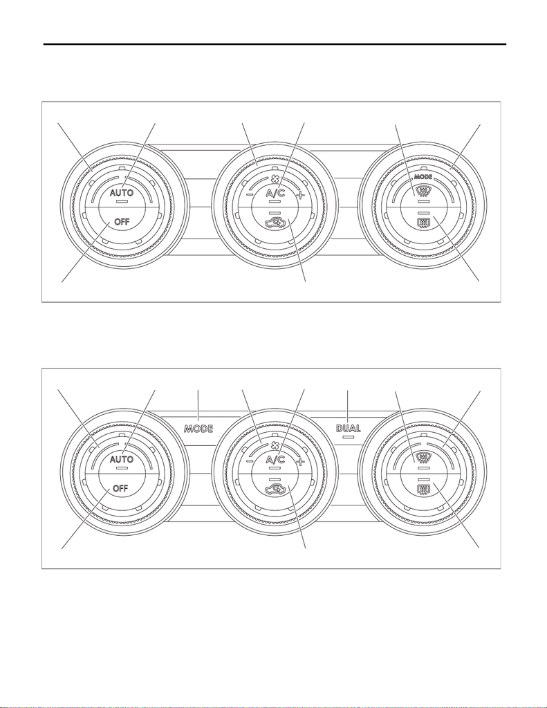

AC(diag)-8

Diagnostic Chart for Self-Diagnosis

HVAC SYSTEM (AUTO A/C) (DIAGNOSTICS)

5. Diagnostic Chart for Self-Diagnosis

A: OPERATION

• Without left/right independent air conditioning function

• With left/right independent air conditioning function

(1) Defroster switch (4) A/C switch (7) OFF switch

(2) Rear window defogger switch (5) Fan dial (8) Temperature adjustment dial

(3) Air flow control dial (6) FRESH/RECIRC switch (9) AUTO switch

(1) Defroster switch (5) Fan dial (8) Temperature adjustment dial

(2) Rear window defogger switch (6) FRESH/RECIRC switch (9) AUTO switch

(3) Air flow control switch (7) OFF switch (10) Dual switch

(4) A/C switch

AC-02748

(3)

(2)

(4)(5)

(6)(7)

AC-02652

(8)

(2)

(3)

(4)(5)

(6)(7)